# Practical-ML-Assignment

Angus Mackenzie

06/12/2021

# Background

Using devices such as Jawbone Up, Nike FuelBand, and Fitbit it is now possible to collect a large amount of data about personal activity relatively inexpensively. These type of devices are part of the quantified self movement – a group of enthusiasts who take measurements about themselves regularly to improve their health, to find patterns in their behavior, or because they are tech geeks. One thing that people regularly do is quantify how much of a particular activity they do, but they rarely quantify how well they do it. In this project, your goal will be to use data from accelerometers on the belt, forearm, arm, and dumbell of 6 participants. They were asked to perform barbell lifts correctly and incorrectly in 5 different ways.

More information is available from the website here: http://web.archive.org/web/20161224072740/http:/groupware.les.inf.puc-rio.br/har (see the section on the Weight Lifting Exercise Dataset).

## Packages

```r
library(tidyverse);library(lubridate);library(factoextra);library(FactoMineR)
library(caret);library(rattle);library(randomForest)
```

## Data Proccessing

We first need to download the data and tidy it up.

```r
#### Data Download
dftrain <- read.csv("https://d396qusza40orc.cloudfront.net/predmachlearn/pml-training.csv")
dftest <- read.csv("https://d396qusza40orc.cloudfront.net/predmachlearn/pml-testing.csv")

#### Convert blank entry to NA
dftrain <- dftrain %>% replace(. == "", NA)

#### Find variables over 75% NA
vvar <- sapply(dftrain, function(x) sum(is.na(x)) )
vvar <- vvar < round(nrow(dftrain)*0.75)

vvar <- names(vvar[vvar])

## Don't include meta information
vvar <- vvar[8:length(vvar)]

dftrain <- select(dftrain, all_of(vvar))

#### Get dependent variable position and make it a factor
ndv <- length(vvar)

dftrain$classe <- as.factor(dftrain$classe)
```

## Principal Component Analysis (PCA)

Now we’ll do PCA to see if there are variables with little effect or are highly correlated.

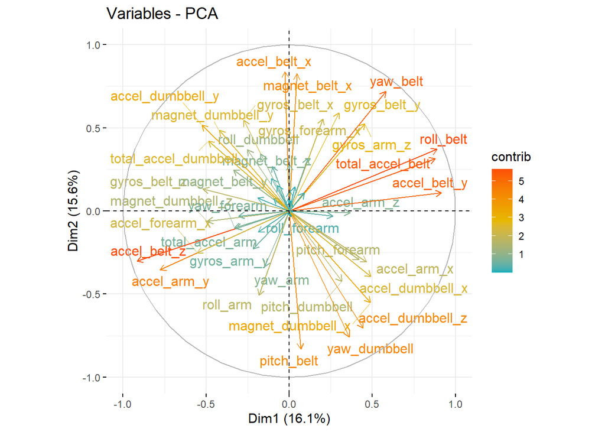

```r
#### PCA
my_PCA <- PCA(dftrain[,-ndv], graph = FALSE)

## Visualize
fviz_pca_var(my_PCA, col.var="contrib", gradient.cols = c("#00AFBB", "#E7B800", "#FC4E07"), repel = TRUE)
```

# Machine Learning

To find best model we are going to split the training data further into training and validation sets

```r
#### Split Validation 20%
smp_size <- floor(0.8 * nrow(dftrain))
vtrain <- sample(seq_len(nrow(dftrain)), size = smp_size)

dfvalid <- dftrain[-vtrain, ]
dftrain <- dftrain[vtrain, ]
```

## Decision Tree

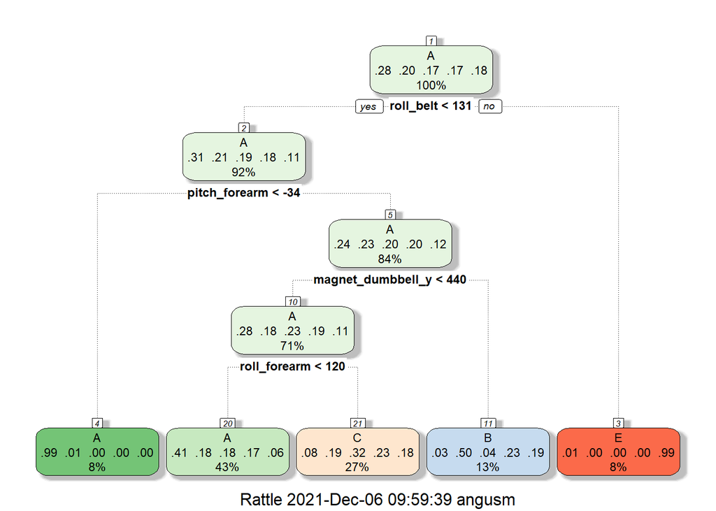

```r
#### Decision TRee
my_rpart <- train(classe ~ ., data = dftrain, method = "rpart")

## Visualize
fancyRpartPlot(my_rpart$finalModel)
```

Lets see how accurate that was:

```r
## Predict
vtree_predict <- predict(my_rpart, dfvalid)

confusionMatrix(vtree_predict, dfvalid$classe)
```

```
## Confusion Matrix and Statistics
##
##           Reference
## Prediction    A    B    C    D    E
##          A 1044  280  329  265   85
##          B   11  265   24  108   98
##          C   88  178  381  238  208
##          D    0    0    0    0    0
##          E    3    0    0    0  320
##
## Overall Statistics
##
##                Accuracy : 0.5121
##                  95% CI : (0.4963, 0.5279)
##     No Information Rate : 0.292
##     P-Value [Acc > NIR] : < 2.2e-16
##
##                   Kappa : 0.3583
##
##  Mcnemar's Test P-Value : NA
##
## Statistics by Class:
##
##                      Class: A Class: B Class: C Class: D Class: E
## Sensitivity            0.9110  0.36653  0.51907   0.0000  0.45007
## Specificity            0.6549  0.92473  0.77687   1.0000  0.99907
## Pos Pred Value         0.5212  0.52372  0.34858      NaN  0.99071
## Neg Pred Value         0.9469  0.86604  0.87535   0.8443  0.89145
## Prevalence             0.2920  0.18420  0.18701   0.1557  0.18115
## Detection Rate         0.2660  0.06752  0.09707   0.0000  0.08153
## Detection Prevalence   0.5103  0.12892  0.27847   0.0000  0.08229
## Balanced Accuracy      0.7830  0.64563  0.64797   0.5000  0.72457
```

## Random Forest

A random forest might work better.

```r
#### Random Forest
my_rf <- randomForest(classe ~ ., data = dftrain)

## Predict
vrf_predict <- predict(my_rf, dfvalid)

confusionMatrix(vrf_predict, dfvalid$classe)
```

```
## Confusion Matrix and Statistics
##
##           Reference
## Prediction    A    B    C    D    E
##          A 1144    2    0    0    0
##          B    1  721    4    0    0
##          C    0    0  729    4    1
##          D    0    0    1  607    0
##          E    1    0    0    0  710
##
## Overall Statistics
##
##                Accuracy : 0.9964
##                  95% CI : (0.994, 0.998)
##     No Information Rate : 0.292
##     P-Value [Acc > NIR] : < 2.2e-16
##
##                   Kappa : 0.9955
##
##  Mcnemar's Test P-Value : NA
##
## Statistics by Class:
##
##                      Class: A Class: B Class: C Class: D Class: E
## Sensitivity            0.9983   0.9972   0.9932   0.9935   0.9986
## Specificity            0.9993   0.9984   0.9984   0.9997   0.9997
## Pos Pred Value         0.9983   0.9931   0.9932   0.9984   0.9986
## Neg Pred Value         0.9993   0.9994   0.9984   0.9988   0.9997
## Prevalence             0.2920   0.1842   0.1870   0.1557   0.1811
## Detection Rate         0.2915   0.1837   0.1857   0.1546   0.1809
## Detection Prevalence   0.2920   0.1850   0.1870   0.1549   0.1811
## Balanced Accuracy      0.9988   0.9978   0.9958   0.9966   0.9991
```

## Predict test data

The random forest was far more successful. Finally we’ll apply the model to the test subjects.

```r
#### Select the same columns as in training
dftest <- select(dftest, all_of(vvar[-ndv]))

## Predict results
predict(my_rf, dftest)
```

```
##  1  2  3  4  5  6  7  8  9 10 11 12 13 14 15 16 17 18 19 20
##  B  A  B  A  A  E  D  B  A  A  B  C  B  A  E  E  A  B  B  B
## Levels: A B C D E
```

**Thank you for grading my assignment**